# Project Python Foundations: FoodHub Data Analysis

### Context

The number of restaurants in New York is increasing day by day. Lots of students and busy professionals rely on those restaurants due to their hectic lifestyles. Online food delivery service is a great option for them. It provides them with good food from their favorite restaurants. A food aggregator company FoodHub offers access to multiple restaurants through a single smartphone app.

The app allows the restaurants to receive a direct online order from a customer. The app assigns a delivery person from the company to pick up the order after it is confirmed by the restaurant. The delivery person then uses the map to reach the restaurant and waits for the food package. Once the food package is handed over to the delivery person, he/she confirms the pick-up in the app and travels to the customer's location to deliver the food. The delivery person confirms the drop-off in the app after delivering the food package to the customer. The customer can rate the order in the app. The food aggregator earns money by collecting a fixed margin of the delivery order from the restaurants.

### Objective

The food aggregator company has stored the data of the different orders made by the registered customers in their online portal. They want to analyze the data to get a fair idea about the demand of different restaurants which will help them in enhancing their customer experience. Suppose you are hired as a Data Scientist in this company and the Data Science team has shared some of the key questions that need to be answered. Perform the data analysis to find answers to these questions that will help the company to improve the business.

### Data Description

The data contains the different data related to a food order. The detailed data dictionary is given below.

### Data Dictionary

- order_id: Unique ID of the order
- customer_id: ID of the customer who ordered the food
- restaurant_name: Name of the restaurant
- cuisine_type: Cuisine ordered by the customer
- cost_of_the_order: Cost of the order
- day_of_the_week: Indicates whether the order is placed on a weekday or weekend (The weekday is from Monday to Friday and the weekend is Saturday and Sunday)
- rating: Rating given by the customer out of 5
- food_preparation_time: Time (in minutes) taken by the restaurant to prepare the food. This is calculated by taking the difference between the timestamps of the restaurant's order confirmation and the delivery person's pick-up confirmation.
- delivery_time: Time (in minutes) taken by the delivery person to deliver the food package. This is calculated by taking the difference between the timestamps of the delivery person's pick-up confirmation and drop-off information

### Let us start by importing the required libraries

```python
# Installing the libraries with the specified version.
!pip install numpy>=1.26
!pip install pandas==2.2.2
!pip install matplotlib>=3.8.0
```

**Note**: *After running the above cell, kindly restart the notebook kernel and run all cells sequentially from the start again.*

```python
# import libraries for data manipulation
import numpy as np
import pandas as pd

# import libraries for data visualization
import matplotlib.pyplot as plt
import seaborn as sns
```

### Understanding the structure of the data

```python
# uncomment and run the following lines for Google Colab
from google.colab import drive
drive.mount('/content/drive')
```

```python
# Write your code here to read the data
df = pd.read_csv('/content/drive/MyDrive/foodhub_order.csv')
```

```python
# Write your code here to view the first 5 rows
df.head()
```

|  | order_id | customer_id | restaurant_name | cuisine_type | cost_of_the_order | day_of_the_week | rating | food_preparation_time | delivery_time |
| --- | --- | --- | --- | --- | --- | --- | --- | --- | --- |
| 0 | 1477147 | 337525 | Hangawi | Korean | 30.75 | Weekend | Not given | 25 | 20 |
| 1 | 1477685 | 358141 | Blue Ribbon Sushi Izakaya | Japanese | 12.08 | Weekend | Not given | 25 | 23 |
| 2 | 1477070 | 66393 | Cafe Habana | Mexican | 12.23 | Weekday | 5 | 23 | 28 |
| 3 | 1477334 | 106968 | Blue Ribbon Fried Chicken | American | 29.20 | Weekend | 3 | 25 | 15 |
| 4 | 1478249 | 76942 | Dirty Bird to Go | American | 11.59 | Weekday | 4 | 25 | 24 |

### **Question 1:** How many rows and columns are present in the data? [0.5 mark]

```python
# Assuming df is your DataFrame
rows, columns = df.shape

# Output the number of rows and columns
print(f'The data has {rows} rows and {columns} columns.')
```

```
The data has 1898 rows and 9 columns.
```

#### Observations: There should be enough data in our dataset for us to glean some insights and perform some basic statistical analysis.

### **Question 2:** What are the datatypes of the different columns in the dataset? (The info() function can be used) [0.5 mark]

```python
df.info()
```

```
<class 'pandas.core.frame.DataFrame'>
RangeIndex: 1898 entries, 0 to 1897
Data columns (total 9 columns):
 #   Column                 Non-Null Count  Dtype
---  ------                 --------------  -----
 0   order_id               1898 non-null   int64
 1   customer_id            1898 non-null   int64
 2   restaurant_name        1898 non-null   object
 3   cuisine_type           1898 non-null   object
 4   cost_of_the_order      1898 non-null   float64
 5   day_of_the_week        1898 non-null   object
 6   rating                 1898 non-null   object
 7   food_preparation_time  1898 non-null   int64
 8   delivery_time          1898 non-null   int64
dtypes: float64(1), int64(4), object(4)
memory usage: 133.6+ KB
```

#### Observations: Our dataset contains 4 categorical and 5 numerical variables (9 columns total)

### **Question 3:** Are there any missing values in the data? If yes, treat them using an appropriate method. [1 mark]

```python
# Replace 'Not given' in 'rating' column with NaN
df['rating'] = df['rating'].replace("Not given", np.nan)

# Replace 'Not given' with NaN in the rating column
df['rating'] = df['rating'].replace("Not given", np.nan)

# Convert the rating column to numeric
df['rating'] = pd.to_numeric(df['rating'])

# Print number of missing values before treatment
print("Missing values in each column:\n", df.isnull().sum())

# Fill missing values using mode without chained assignment
mode_rating = df['rating'].mode()[0]
df['rating'] = df['rating'].fillna(mode_rating)

# Confirm all missing values have been treated
print("\nMissing values after treatment:\n", df.isnull().sum())
```

```
Missing values in each column:
 order_id                   0
customer_id                0
restaurant_name            0
cuisine_type               0
cost_of_the_order          0
day_of_the_week            0
rating                   736
food_preparation_time      0
delivery_time              0
dtype: int64

Missing values after treatment:
 order_id                 0
customer_id              0
restaurant_name          0
cuisine_type             0
cost_of_the_order        0
day_of_the_week          0
rating                   0
food_preparation_time    0
delivery_time            0
dtype: int64
```

#### Observations: There were 736 "not given" responses for the rating variable. I replaced the missing responses with the mode for the variable. Although I treated the missing observations by adding the mode response in their place, the rating variable is likely to be less reliable than others becuase roughly 38% of its acutal values were missing.

### **Question 4:** Check the statistical summary of the data. What is the minimum, average, and maximum time it takes for food to be prepared once an order is placed? [2 marks]

```python
# Get the statistical summary
summary = df['food_preparation_time'].describe()

# Extract the required statistics
minimum_time = summary['min']
average_time = summary['mean']
maximum_time = summary['max']

# Print the results
print(f"Minimum preparation time: {minimum_time} minutes")
print(f"Average preparation time: {average_time} minutes")
print(f"Maximum preparation time: {maximum_time} minutes")
```

```
Minimum preparation time: 20.0 minutes
Average preparation time: 27.371970495258168 minutes
Maximum preparation time: 35.0 minutes
```

#### Observations: Variance is low. No obvious outliers looking at this output.

### **Question 5:** How many orders are not rated? [1 mark]

```python
# Replace 'Not given' in 'rating' column with NaN
df['rating'] = df['rating'].replace("Not given", np.nan)

# Replace 'Not given' with NaN in the rating column
df['rating'] = df['rating'].replace("Not given", np.nan)

# Convert the rating column to numeric
df['rating'] = pd.to_numeric(df['rating'])

# Print number of missing values before treatment
print("Missing values in each column:\n", df.isnull().sum())

# Fill missing values using mode without chained assignment
mode_rating = df['rating'].mode()[0]
df['rating'] = df['rating'].fillna(mode_rating)

# Confirm all missing values have been treated
print("\nMissing values after treatment:\n", df.isnull().sum())
```

```
Missing values in each column:
 order_id                 0
customer_id              0
restaurant_name          0
cuisine_type             0
cost_of_the_order        0
day_of_the_week          0
rating                   0
food_preparation_time    0
delivery_time            0
dtype: int64

Missing values after treatment:
 order_id                 0
customer_id              0
restaurant_name          0
cuisine_type             0
cost_of_the_order        0
day_of_the_week          0
rating                   0
food_preparation_time    0
delivery_time            0
dtype: int64
```

:#### Observations: As stated in question 3, there were 736 missing ratings. I treated the missing data as instructed above, thus the output directly above says there's currently no missing data. However, the rating variable is likely to be less reliable than others in our dataset becuase roughly 38% of its acutal values were missing.

### Exploratory Data Analysis (EDA)

### **Question 6:** Explore all the variables and provide observations on their distributions. (Generally, histograms, boxplots, countplots, etc. are used for univariate exploration.) [9 marks]

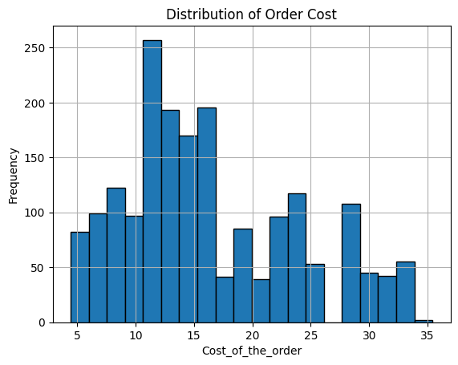

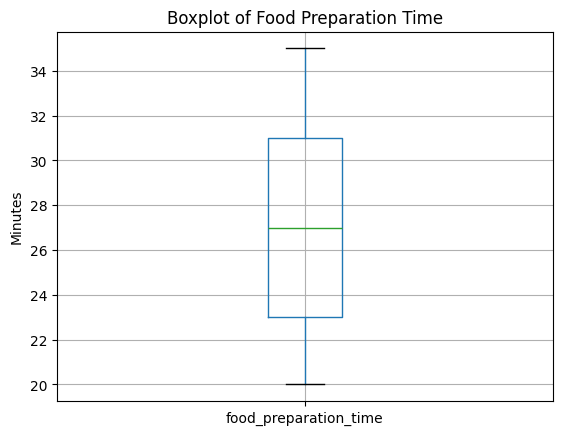

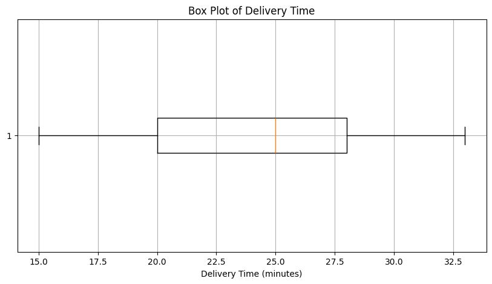

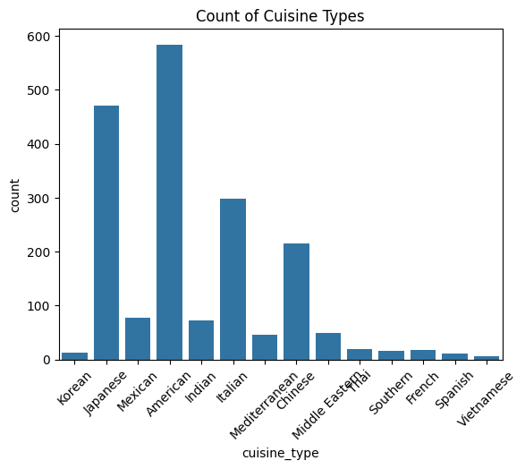

```python
# Histogram for distribution of order cost
df['cost_of_the_order'].hist(bins=20, edgecolor='k')
plt.title('Distribution of Order Cost')
plt.xlabel('Cost_of_the_order')
plt.ylabel('Frequency')
plt.show()

# Boxplot of food preparation time
df.boxplot(column='food_preparation_time')
plt.title('Boxplot of Food Preparation Time')
plt.ylabel('Minutes')
plt.show()

# Box plot for delivery_time
plt.figure(figsize=(10, 5))
plt.boxplot(df['delivery_time'], vert=False)
plt.title('Box Plot of Delivery Time')
plt.xlabel('Delivery Time (minutes)')
plt.grid(True)
plt.show()

# Countplot for cuisine type
sns.countplot(data=df, x='cuisine_type')
plt.title('Count of Cuisine Types')
plt.xticks(rotation=45)
plt.show()
```

### **Question 7**: Which are the top 5 restaurants in terms of the number of orders received? [1 mark]

```python
# Group by restaurant_name and count the number of orders
restaurant_orders = df.groupby('restaurant_name')['order_id'].count()

# Sort the counts in descending order and select the top 5
top_5_restaurants = restaurant_orders.sort_values(ascending=False).head(5)

# Print the top 5 restaurants with their order counts
print(top_5_restaurants)
```

```
restaurant_name
Shake Shack                  219
The Meatball Shop            132
Blue Ribbon Sushi            119
Blue Ribbon Fried Chicken     96
Parm                          68
Name: order_id, dtype: int64
```

#### Observations: Shake Shack is the most ordered restaurant by far. Blue Ribbon has two resturants in the top 5 indicating it's potentially a strong brand in the area.

### **Question 8**: Which is the most popular cuisine on weekends? [1 mark]

```python
# Filter the data for weekend orders
weekend_data = df[df['day_of_the_week'].isin(['Weekend'])]

# Check if weekend_data is empty
if weekend_data.empty:
    print("No orders found on weekends.")
else:
    # Count the occurrences of each cuisine type on weekends
    cuisine_counts = weekend_data['cuisine_type'].value_counts()

    # Identify the most popular cuisine
    most_popular_cuisine = cuisine_counts.idxmax()
    most_popular_count = cuisine_counts.max()

    # Print the result
    print(f"The most popular cuisine on weekends is {most_popular_cuisine} with {most_popular_count} orders.")
```

```
The most popular cuisine on weekends is American with 415 orders.
```

#### Observations: The most popular cuisine on weekends is American with 415 orders. This is also the most popular cuisine overall with almost 600 orders. The 415 weekend orders represents over two thirds of the 600 total orders for the most popular cuisine. The 415 weekend orders of American cuisine represent roughly twenty two percent of all of the orders placed.

### **Question 9**: What percentage of the orders cost more than 20 dollars? [2 marks]

```python
# Calculate the percentage of orders that cost more than $20
high_cost_orders = df[df['cost_of_the_order'] > 20]  # Filter orders above $20
percentage_high_cost = (len(high_cost_orders) / len(df)) * 100  # Compute percentage

print(f"Percentage of orders costing more than $20: {percentage_high_cost:.2f}%")
```

```
Percentage of orders costing more than $20: 29.24%
```

#### Observations: Under 30 percent of the orders are over 20 dollars. How might such low order prices on roughy 70 percent of FoodHub's orders be effecting the bottom line of the company? The problem statement says 'the food aggregator earns money by collecting a fixed margin of the delivery order from the restaurant.' It doesn't say exactly what the margin FoodHub earns on each order is. It's definitely possible that this is seriously limiting the company's ability to generate revenue.

### **Question 10**: What is the mean order delivery time? [1 mark]

```python
# Calculate the mean (average) delivery time
mean_delivery_time = df['delivery_time'].mean()

print(f"Mean delivery time: {mean_delivery_time:.2f} minutes")
```

```
Mean delivery time: 24.16 minutes
```

#### Observations: A mean time of about 24 minutes appears to show that the delivery service is efficient.

### **Question 11:** The company has decided to give 20% discount vouchers to the top 3 most frequent customers. Find the IDs of these customers and the number of orders they placed. [1 mark]

```python
# Identify the top 3 most frequent customers based on order count
top_customers = df['customer_id'].value_counts().head(3)

# Extract the top 3 customer IDs
top_customer_ids = top_customers.index.tolist()

# Filter the dataset for only these top customers
top_customers_data = df[df['customer_id'].isin(top_customer_ids)]

# Calculate the average order cost for each top customer
avg_order_cost_per_customer = top_customers_data.groupby('customer_id')['cost_of_the_order'].mean()

# Find the most frequently ordered restaurants for each top customer
top_restaurants_per_customer = top_customers_data.groupby('customer_id')['restaurant_name'].agg(lambda x: x.value_counts().idxmax())

# Combine results into a DataFrame for easy viewing
top_customers_analysis = pd.DataFrame({
    'Average Order Cost': avg_order_cost_per_customer,
    'Most Ordered Restaurant': top_restaurants_per_customer
})

# Print the results
print("Top 3 Customers Analysis:\n")
print(top_customers_analysis)
```

```
Top 3 Customers Analysis:

             Average Order Cost    Most Ordered Restaurant
customer_id
47440                 15.818000                 Bareburger
52832                 17.369231                 Donburi-ya
83287                 15.478889  Blue Ribbon Sushi Izakaya
```

### **Question 12**: Perform a multivariate analysis to explore relationships between the important variables in the dataset. (It is a good idea to explore relations between numerical variables as well as relations between numerical and categorical variables) [10 marks]

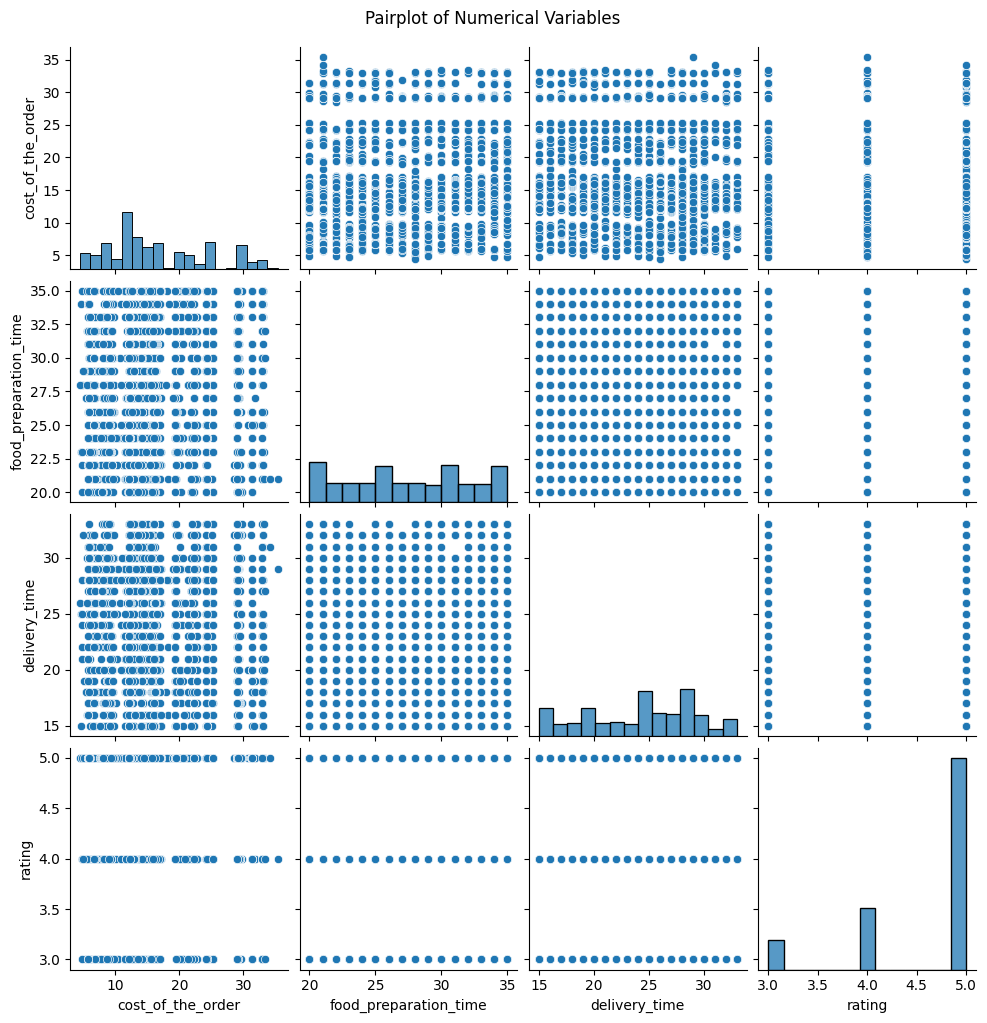

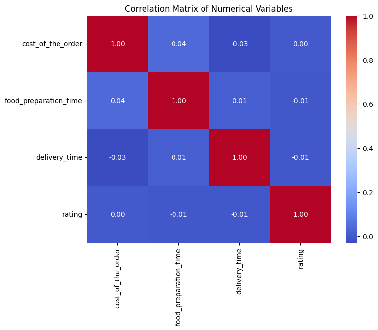

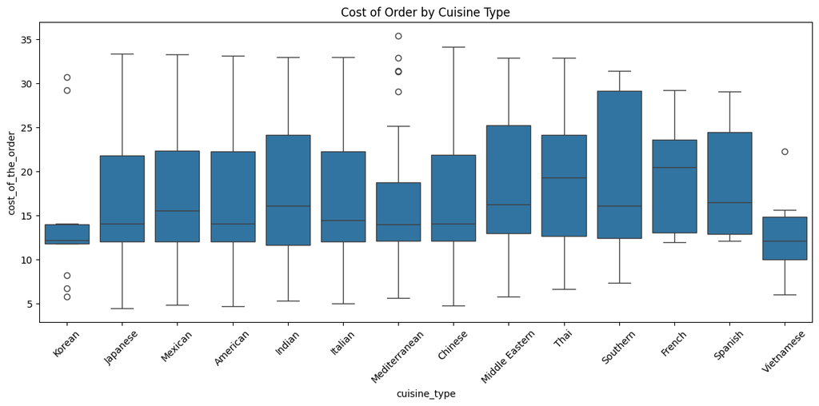

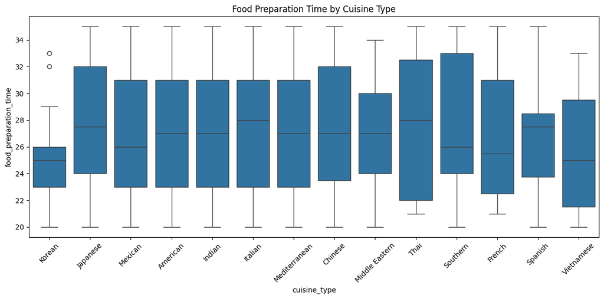

```python
# Pairplot of Numerical Variables
# =============================
numerical_vars = ['cost_of_the_order', 'food_preparation_time', 'delivery_time', 'rating']

# Drop rows with missing numerical data for pairplot
sns.pairplot(df[numerical_vars].dropna())
plt.suptitle("Pairplot of Numerical Variables", y=1.02)
plt.show()

# Correlation Matrix Heatmap
corr = df[numerical_vars].corr()

plt.figure(figsize=(8, 6))
sns.heatmap(corr, annot=True, cmap='coolwarm', fmt=".2f")
plt.title("Correlation Matrix of Numerical Variables")
plt.show()

# Boxplot: Cost of Order by Cuisine Type
plt.figure(figsize=(12, 6))
sns.boxplot(x='cuisine_type', y='cost_of_the_order', data=df)
plt.xticks(rotation=45)
plt.title("Cost of Order by Cuisine Type")
plt.tight_layout()
plt.show()

# Boxplot: Food Preparation Time by Cuisine Type
plt.figure(figsize=(12, 6))
sns.boxplot(x='cuisine_type', y='food_preparation_time', data=df)
plt.xticks(rotation=45)
plt.title("Food Preparation Time by Cuisine Type")
plt.tight_layout()
plt.show()
```

### **Question 13:** The company wants to provide a promotional offer in the advertisement of the restaurants. The condition to get the offer is that the restaurants must have a rating count of more than 50 and the average rating should be greater than 4. Find the restaurants fulfilling the criteria to get the promotional offer. [3 marks]

```python
# Group by restaurant and calculate rating count and average rating
restaurant_stats = df.groupby('restaurant_name')['rating'].agg(
    rating_count='count',
    avg_rating='mean'
).reset_index()

# Filter restaurants that meet the promotional criteria
promotional_restaurants = restaurant_stats[
    (restaurant_stats['rating_count'] > 50) &
    (restaurant_stats['avg_rating'] > 4)
]

# Display the results
print("Restaurants eligible for promotional offers:")
print(promotional_restaurants)
```

```
Restaurants eligible for promotional offers:
               restaurant_name  rating_count  avg_rating
20   Blue Ribbon Fried Chicken            96    4.552083
21           Blue Ribbon Sushi           119    4.521008
109                       Parm            68    4.500000
121           RedFarm Broadway            59    4.474576
122             RedFarm Hudson            55    4.490909
136                Shake Shack           219    4.561644
153          The Meatball Shop           132    4.689394
```

### **Question 14:** The company charges the restaurant 25% on the orders having cost greater than 20 dollars and 15% on the orders having cost greater than 5 dollars. Find the net revenue generated by the company across all orders. [3 marks]

```python
# Define a function to calculate commission for each order
def calculate_commission(order_cost):
    if order_cost > 20:
        return order_cost * 0.25
    elif order_cost > 5:
        return order_cost * 0.15
    else:
        return 0

# Apply the function to calculate commission for each order
df['commission'] = df['cost_of_the_order'].apply(calculate_commission)

# Calculate the total net revenue
total_net_revenue = df['commission'].sum()

print(f"Total net revenue generated by the company: ${total_net_revenue:.2f}")
```

```
Total net revenue generated by the company: $6166.30
```

#### Observations: The net revenue of 6,166.30 is approximately 3.25 per order on average (6,166.30/1898).

### **Question 15:** The company wants to analyze the total time required to deliver the food. What percentage of orders take more than 60 minutes to get delivered from the time the order is placed? (The food has to be prepared and then delivered.) [2 marks]

```python
# Calculate the total time for each order
df['total_time'] = df['food_preparation_time'] + df['delivery_time']

# Count the number of orders exceeding 60 minutes
orders_over_60 = df[df['total_time'] > 60].shape[0]

# Calculate the total number of orders
total_orders = df.shape[0]

# Compute the percentage of orders taking more than 60 minutes
percentage_over_60 = (orders_over_60 / total_orders) * 100

print(f"Percentage of orders taking more than 60 minutes: {percentage_over_60:.2f}%")
```

```
Percentage of orders taking more than 60 minutes: 10.54%
```

#### Observations:The percentage of orders that take more than 60 minutes to get delivered from the time the order is placed is 10.54 percent. A delivery time of less than 60 minutes for almost 90 percent of orders means customers will generally receive their food in less than one hour using the service.

### **Question 16:** The company wants to analyze the delivery time of the orders on weekdays and weekends. How does the mean delivery time vary during weekdays and weekends? [2 marks]

```python
# Group by day_of_the_week and calculate mean delivery time
mean_delivery_time = df.groupby('day_of_the_week')['delivery_time'].mean().reset_index()

# Rename columns for clarity
mean_delivery_time.columns = ['Day Type', 'Average Delivery Time (minutes)']

# Display the result
print(mean_delivery_time)
```

```
  Day Type  Average Delivery Time (minutes)
0  Weekday                        28.340037
1  Weekend                        22.470022
```

### Recommendations:

#### *Improve the process for requesting ratings. WIth roughly 38 percent of customers not responding with a rating it will be hard to effectively evaluate the service. Is the process too time consuming or complex? Can it be simplified? What happens if a customer doesn't respond to a rating request? Are they asked again/reminded? Is it possible to ask customers to customers more than once if we're not already? Is the one to five star rating system really capturing the information needed to evaluate the service? This system may tell us if a customer really liked or disliked their overall experience. However, it doesn't tell us what they really liked or disliked about it. Capturing specific data for this variable is essential to evaluating figuring out what areas of the service are providing value to the customers and what parts could be improved to create more value for them.

#### *How might such low order prices on roughly 70 percent of FoodHub's orders be affecting the company's bottom line? The average price of the orders from the top three most frequent customers is significantly below 20 dollars. Does it make sense to offer targeted promotions encouraging these customers to place larger orders, possibly steering them toward menu items or combinations that have a greater profit margin for FoodHub? Consider a minimum order for service. Does it make sense to have a minimum order in place? According to question 14 "The company charges the restaurant 25% on the orders having cost greater than 20 dollars and 15% on the orders having cost greater than 5 dollars. Find the net revenue generated by the company across all orders." That means on an order of 30 dollars FoodHub makes approximately 7.50. Is it worth it for the company to provide service for any less of a margin than this? How likely are customers to pay the additional money for the convenience of having their food delivered?

#### *The categorical variable cuisine_type has a noticeable impact on cost_of_the_order. Consider expanding the selection of restaurants serving the types of cuisine with higher order costs and dropping the ones with lower order costs. Although food_preparation_time may increase with these cuisines, the analysis shows it's not signficant enough to prohibit the service from focusing on the more expensive cuisine types.